# RNA Seq deseq2

## Normalising gene expression distributions

La normalisation est nécessaire pour s’assurer que les distributions d’expression de chaque échantillon sont similaires dans l’ensemble de l’expérience.

```r
x <- calcNormFactors(x, method = "TMM")
x$samples$norm.factors
```

```
[1] 0.8943956 1.0250186 1.0459005 1.0458455 1.0162707 0.9217132 0.9961959 1.0861026
[9] 0.9839203
```

```r
x2 <- x
x2$samples$norm.factors <- 1
x2$counts[,1] <- ceiling(x2$counts[,1]*0.05)
x2$counts[,2] <- x2$counts[,2]*5
```

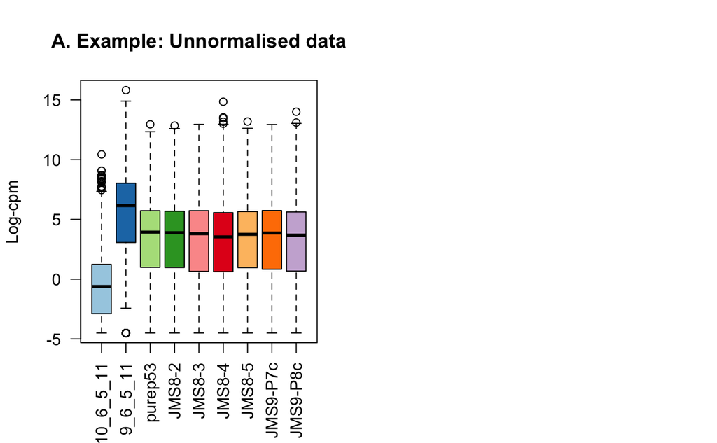

```r
# code pour produire la figure

par(mfrow=c(1,2))
lcpm <- cpm(x2, log=TRUE)
boxplot(lcpm, las=2, col=col, main="")
title(main="A. Example: Unnormalised data",ylab="Log-cpm")
```

```r
x2 <- calcNormFactors(x2)
x2$samples$norm.factors
```

```
[1] 0.05770899 6.08287835 1.22023972 1.16478991 1.19661094 1.04659233 1.15048074 1.25431164
[9] 1.10901983
```

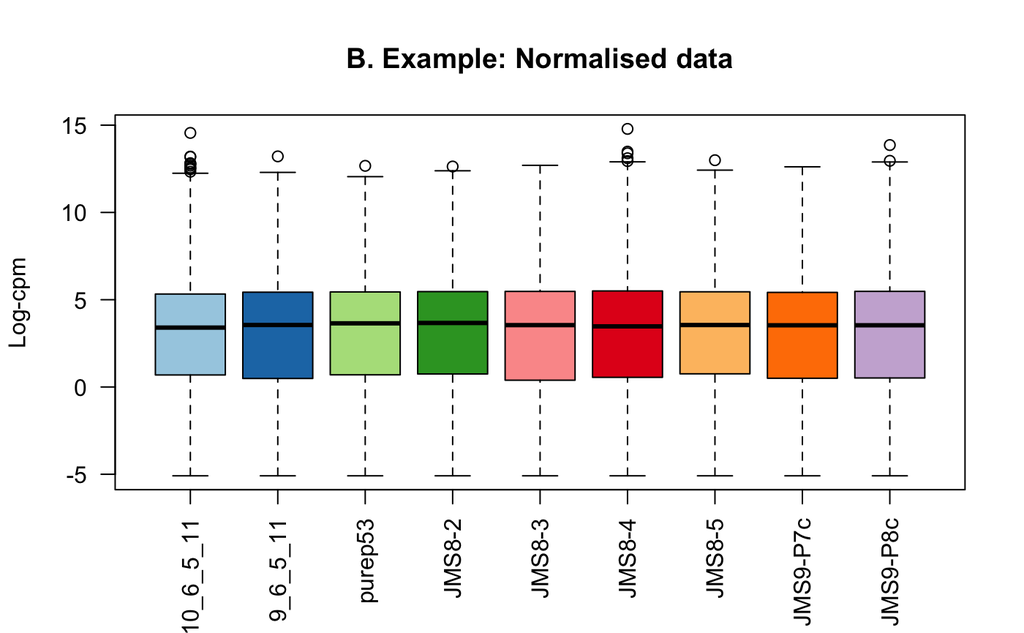

```r
# code pour produire la figure

lcpm <- cpm(x2, log=TRUE)
boxplot(lcpm, las=2, col=col, main="")
title(main="B. Example: Normalised data",ylab="Log-cpm")
```

## Unsupervised clustering of samples

Le graphique montre les similitudes et les dissemblances entre les échantillons de manière non supervisée afin que l’on puisse avoir une idée de la mesure dans laquelle l’expression différentielle peut être détectée avant d’effectuer des tests formels.

```r
lcpm <- cpm(x, log=TRUE)
par(mfrow=c(1,2))
col.group <- group
levels(col.group) <-  brewer.pal(nlevels(col.group), "Set1")
col.group <- as.character(col.group)
col.lane <- lane
levels(col.lane) <-  brewer.pal(nlevels(col.lane), "Set2")
col.lane <- as.character(col.lane)
plotMDS(lcpm, labels=group, col=col.group)
title(main="A. Sample groups")
```

[figure not shown]

```r
plotMDS(lcpm, labels=lane, col=col.lane, dim=c(3,4))
title(main="B. Sequencing lanes")
```

```r
glMDSPlot(lcpm, labels=paste(group, lane, sep="_"),
          groups=x$samples[,c(2,5)], launch=FALSE)
```

# Differential expression analysis

## Creating a design matrix and contrasts

voir quels gènes sont exprimés à différents niveaux entre les trois populations cellulaires profilées.

```r
#configurer une matrice de conception avec les info de la pop C
design <- model.matrix(~0+group+lane)
colnames(design) <- gsub("group", "", colnames(design))
design
```

```
  Basal LP ML laneL006 laneL008
1     0  1  0        0        0
2     0  0  1        0        0
3     1  0  0        0        0
4     1  0  0        1        0
5     0  0  1        1        0
6     0  1  0        1        0
7     1  0  0        1        0
8     0  0  1        0        1
9     0  1  0        0        1
attr(,"assign")
[1] 1 1 1 2 2
attr(,"contrasts")
attr(,"contrasts")$group
[1] "contr.treatment"

attr(,"contrasts")$lane
[1] "contr.treatment"
```

```r
# mis en place des contrastes pour les comparaisons par paires entre les populations cellulaires

contr.matrix <- makeContrasts(
   BasalvsLP = Basal-LP,
   BasalvsML = Basal - ML,
   LPvsML = LP - ML,
   levels = colnames(design))
contr.matrix
```

```
          Contrasts
Levels     BasalvsLP BasalvsML LPvsML
  Basal            1         1      0
  LP              -1         0      1
  ML               0        -1     -1
  laneL006         0         0      0
  laneL008         0         0      0
```

## Removing heteroscedascity from count data

Les moyennes (axe des x) et les variances (axe des y) de chaque gène sont tracées pour montrer la dépendance entre les deux La tendance a diminuer est supprimée après l’application des poids de précision

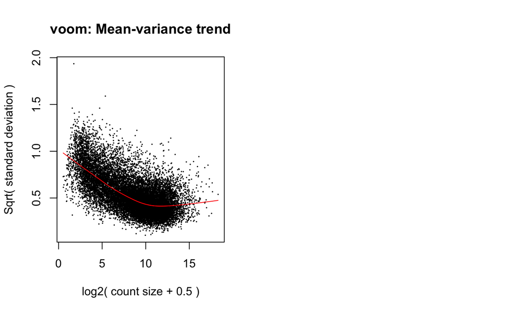

```r
par(mfrow=c(1,2))
v <- voom(x, design, plot=TRUE)
```

```r
v
```

```
An object of class "EList"
$genes
```

|  | ENTREZID | SYMBOL | TXCHROM |
| --- | --- | --- | --- |
| 1 | 497097 | Xkr4 | chr1 |
| 5 | 20671 | Sox17 | chr1 |
| 6 | 27395 | Mrpl15 | chr1 |
| 7 | 18777 | Lypla1 | chr1 |
| 9 | 21399 | Tcea1 | chr1 |

```
16619 more rows ...

$targets
```

|  | files | group | lib.size | norm.factors | lane |
| --- | --- | --- | --- | --- | --- |
| 10_6_5_11 | GSM1545535_10_6_5_11.txt | LP | 29387429 | 0.8943956 | L004 |
| 9_6_5_11 | GSM1545536_9_6_5_11.txt | ML | 36212498 | 1.0250186 | L004 |
| purep53 | GSM1545538_purep53.txt | Basal | 59771061 | 1.0459005 | L004 |
| JMS8-2 | GSM1545539_JMS8-2.txt | Basal | 53711278 | 1.0458455 | L006 |
| JMS8-3 | GSM1545540_JMS8-3.txt | ML | 77015912 | 1.0162707 | L006 |
| JMS8-4 | GSM1545541_JMS8-4.txt | LP | 55769890 | 0.9217132 | L006 |
| JMS8-5 | GSM1545542_JMS8-5.txt | Basal | 54863512 | 0.9961959 | L006 |
| JMS9-P7c | GSM1545544_JMS9-P7c.txt | ML | 23139691 | 1.0861026 | L008 |
| JMS9-P8c | GSM1545545_JMS9-P8c.txt | LP | 19634459 | 0.9839203 | L008 |

```
$E
        Samples
Tags     10_6_5_11  9_6_5_11   purep53     JMS8-2    JMS8-3    JMS8-4    JMS8-5   JMS9-P7c
  497097 -4.292165 -3.856488 2.5185849  3.2931366 -4.459730 -3.994060 3.2869677 -3.2103696
  20671  -4.292165 -4.593453 0.3560126 -0.4073032 -1.200995 -1.943434 0.8442767 -0.3228444
  27395   3.876089  4.413107 4.5170045  4.5617546  4.344401  3.786363 3.8990635  4.3396075
  18777   4.708774  5.571872 5.3964008  5.1623650  5.649355  5.081611 5.0602470  5.7513694
  21399   4.785541  4.754537 5.3703795  5.1220551  4.869586  4.943840 5.1384776  5.0308985
        Samples
Tags      JMS9-P8c
  497097 -5.295316
  20671  -1.207853
  27395   4.124644
  18777   5.142436
  21399   4.979644
16619 more rows ...

$weights
          [,1]      [,2]      [,3]      [,4]      [,5]      [,6]      [,7]      [,8]
[1,]  1.079413  1.332986 19.826915 20.273253  1.993686  1.395853 20.494977  1.107780
[2,]  1.170357  1.456380  4.804866  8.660025  3.612508  2.626870  8.760149  3.211473
[3,] 20.219073 25.573792 30.434759 28.528310 31.352260 25.743247 28.722497 21.200072
[4,] 26.947557 32.505933 33.583128 33.232125 34.231754 32.354158 33.334340 30.348630
[5,] 26.610864 28.501638 33.645479 33.206374 33.573492 31.996623 33.308490 25.171513
          [,9]
[1,]  1.079413
[2,]  2.541942
[3,] 16.657930
[4,] 24.259801
[5,] 23.573305
16619 more rows ...

$design
  Basal LP ML laneL006 laneL008
1     0  1  0        0        0
2     0  0  1        0        0
3     1  0  0        0        0
4     1  0  0        1        0
5     0  0  1        1        0
6     0  1  0        1        0
7     1  0  0        1        0
8     0  0  1        0        1
9     0  1  0        0        1
attr(,"assign")
[1] 1 1 1 2 2
attr(,"contrasts")
attr(,"contrasts")$group
[1] "contr.treatment"

attr(,"contrasts")$lane
[1] "contr.treatment"
```

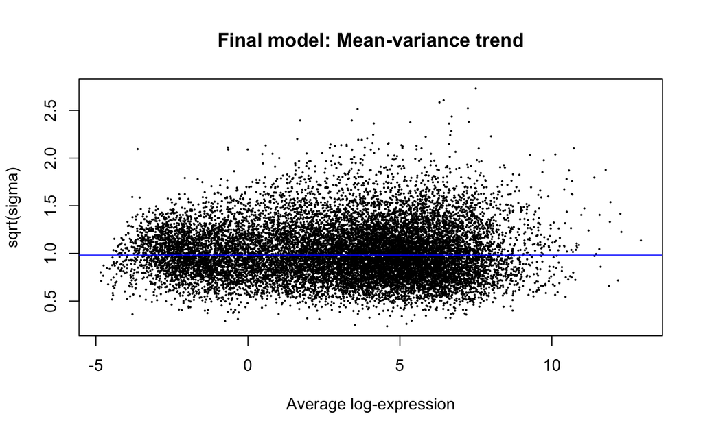

```r
vfit <- lmFit(v, design)
vfit <- contrasts.fit(vfit, contrasts=contr.matrix)
efit <- eBayes(vfit)
plotSA(efit, main="Final model: Mean-variance trend")
```

## Examining the number of DE genes

```r
# résumé du nombre de gènes significativement régulés à la hausse et à la baisse, pour un aperçu rapide des niveaux d’expression différentiels
# valeurs exprimer selo le seuil de p-value

summary(decideTests(efit))
```

```
       BasalvsLP BasalvsML LPvsML
Down        4648      4927   3135
NotSig      7113      7026  10972
Up          4863      4671   2517
```

```r
# en plus de la p-value on ajoute une valeur minimale aux log-fold-changes (log-FC)

tfit <- treat(vfit, lfc=1)
dt <- decideTests(tfit)
summary(dt)
```

```
       BasalvsLP BasalvsML LPvsML
Down        1632      1777    224
NotSig     12976     12790  16210
Up          2016      2057    190
```

```r
# 0 représente les gènes qui ne sont pas DE, 1 ceux qui sont régulés à la hausse et -1 à la baisse => identifier les gènes DE

de.common <- which(dt[,1]!=0 & dt[,2]!=0)
length(de.common)
```

```
[1] 2784
```

```r
head(tfit$genes$SYMBOL[de.common], n=20)
```

```
 [1] "Xkr4"          "Rgs20"         "Cpa6"          "A830018L16Rik" "Sulf1"
 [6] "Eya1"          "Msc"           "Sbspon"        "Pi15"          "Crispld1"
[11] "Kcnq5"         "Rims1"         "Khdrbs2"       "Ptpn18"        "Prss39"
[16] "Arhgef4"       "Cnga3"         "Cracdl"        "Aff3"          "Npas2"
```

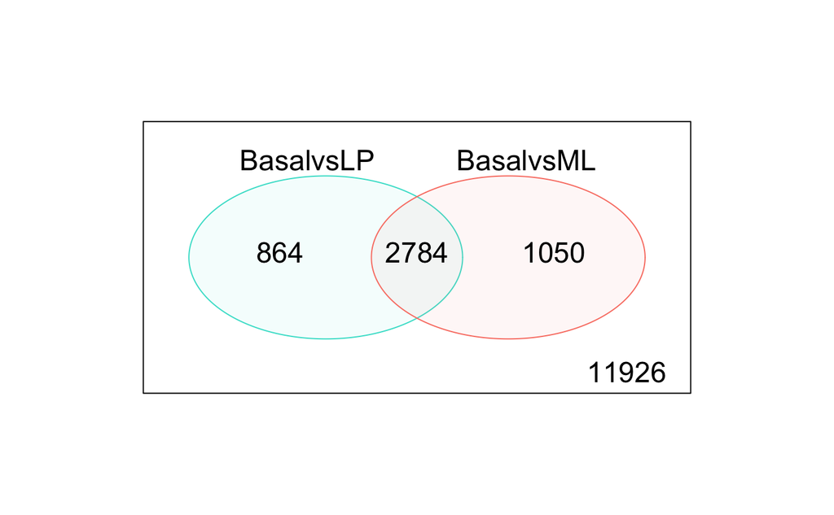

```r
vennDiagram(dt[,1:2], circle.col=c("turquoise", "salmon"))
```

```r
write.fit(tfit, dt, file="results.txt")
```

## Examining individual DE genes from top to bottom

```r
# répertoire des gènes DE

basal.vs.lp <- topTreat(tfit, coef=1, n=Inf)
basal.vs.ml <- topTreat(tfit, coef=2, n=Inf)
head(basal.vs.lp)
```

|  | ENTREZID | SYMBOL | TXCHROM | logFC | AveExpr | t | P.Value | adj.P.Val |
| --- | --- | --- | --- | --- | --- | --- | --- | --- |
| 12759 | 12759 | Clu | chr14 | -5.455444 | 8.856581 | -33.55508 | 1.723731e-10 | 1.707586e-06 |
| 53624 | 53624 | Cldn7 | chr11 | -5.527356 | 6.295437 | -31.97515 | 2.576972e-10 | 1.707586e-06 |
| 242505 | 242505 | Rasef | chr4 | -5.935249 | 5.118259 | -31.33407 | 3.081544e-10 | 1.707586e-06 |
| 67451 | 67451 | Pkp2 | chr16 | -5.738665 | 4.419170 | -29.85616 | 4.575686e-10 | 1.739242e-06 |
| 228543 | 228543 | Rhov | chr2 | -6.264208 | 5.485314 | -29.07484 | 5.782844e-10 | 1.739242e-06 |
| 70350 | 70350 | Basp1 | chr15 | -6.084738 | 5.247023 | -28.26649 | 7.267694e-10 | 1.739242e-06 |

```r
head(basal.vs.ml)
```

|  | ENTREZID | SYMBOL | TXCHROM | logFC | AveExpr | t | P.Value | adj.P.Val |
| --- | --- | --- | --- | --- | --- | --- | --- | --- |
| 242505 | 242505 | Rasef | chr4 | -6.534668 | 5.118259 | -35.08270 | 1.226399e-10 | 1.236213e-06 |
| 53624 | 53624 | Cldn7 | chr11 | -5.495888 | 6.295437 | -31.68918 | 2.774140e-10 | 1.236213e-06 |
| 12521 | 12521 | Cd82 | chr2 | -4.690834 | 7.069637 | -31.43063 | 2.913572e-10 | 1.236213e-06 |
| 20661 | 20661 | Sort1 | chr3 | -4.931660 | 6.704459 | -30.70113 | 3.558720e-10 | 1.236213e-06 |
| 71740 | 71740 | Nectin4 | chr1 | -5.581283 | 5.164967 | -30.59775 | 3.718157e-10 | 1.236213e-06 |
| 12759 | 12759 | Clu | chr14 | -4.686826 | 8.856581 | -27.95760 | 7.687544e-10 | 1.480434e-06 |

## Useful graphical representations of differential expression results

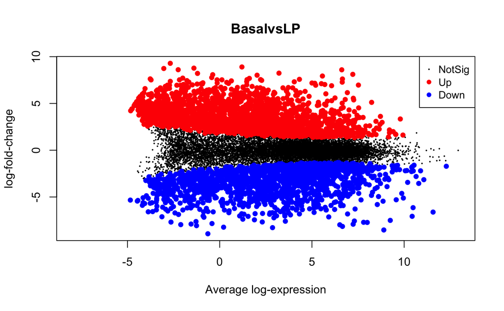

```r
# affiche les log-FCs du modèle linéaire ajustés par rapport aux valeurs moyennes de log-CPM

plotMD(tfit, column=1, status=dt[,1], main=colnames(tfit)[1],
       xlim=c(-8,13))
```

```r
glMDPlot(tfit, coef=1, status=dt, main=colnames(tfit)[1],
         side.main="ENTREZID", counts=lcpm, groups=group, launch=FALSE)
```

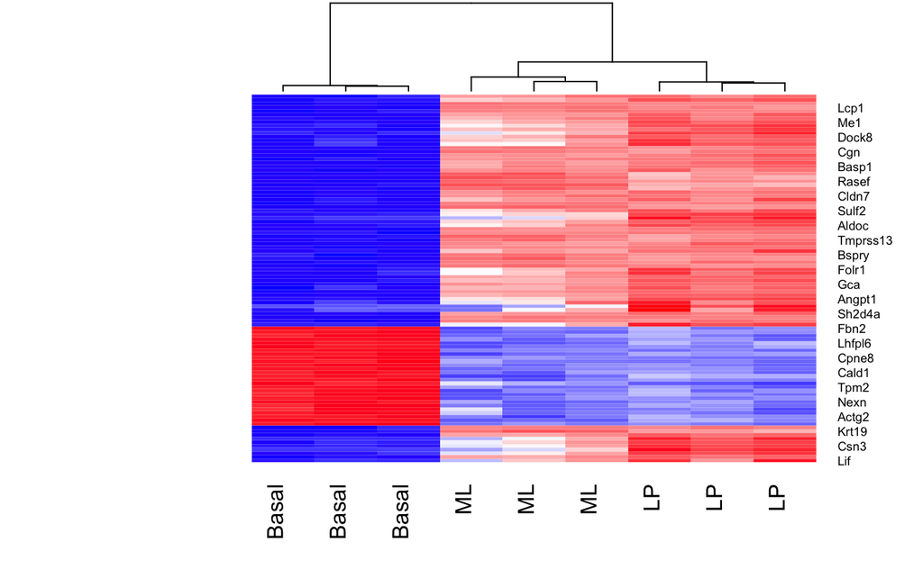

```r
basal.vs.lp.topgenes <- basal.vs.lp$ENTREZID[1:100]
i <- which(v$genes$ENTREZID %in% basal.vs.lp.topgenes)
mycol <- colorpanel(1000,"blue","white","red")


heatmap.2(lcpm[i,], scale="row", width = 35, height = 500,
   labRow=v$genes$SYMBOL[i], labCol=group,
   col=mycol, trace="none", density.info="none",
    lhei=c(2,10), dendrogram="column")
```